# Convex.jl - A native Julia package for real or complex domain Convex Optimization

## Ayush Pandey | PyData Delhi 2017

https://github.com/Ayush-iitkgp/PyData2017Presentation

# About Me

- **BS and MS in Mathematics and Computing Sciences (July'12-June'17) at Indian Institute of Technology Kharagpur**
- **Google Summer of Code 2016 and 2017 student under the Julia Language**
- **GitHub:** [Ayush-iitkgp](https://github.com/ayush-iitkgp)
- **Website:** https://ayush-iitkgp.github.io

# Outline

### Introduction to Julia Programming Language

- Fundamental difference between Julia and Python

### Convex Optimization

### Why Convex.jl?

### Tutorial

### Use Cases

- Portfolio Optimization
- Logistic Regression
- Fidelity in Quantum Information

### Benchmarking

# Introduction to Julia Programming Language

- Free and open source (MIT licensed) high level programming language for high performance scientific computing.
- Very much pythonic in syntax.
- Deploys [just-in-time (JIT)](https://en.wikipedia.org/wiki/Just-in-time_compilation) compilation, implemented using LLVM
- Arrays are 1-indexed.
- Awesome Julia [tutorials](https://www.youtube.com/watch?v=vWkgEddb4-A) at SciPy 2014 by David Sanders.

## Fundamental difference between Julia and Python

```julia
a = 1
b = 2
c = a + b
```

### Python Addition

- Here the python interpreter knows only that 1 and 2 are objects, but not what type of object they are.

#### Step 1: Assign 1 to a

> **1a.** Set a->PyObject_HEAD->typecode to integer

> **1b.** Set a->val = 1

#### Step 2: Assign 2 to b

> **2a.** Set b->PyObject_HEAD->typecode to integer

> **2b.** Set b->val = 2

#### Step 3: call binary_add(a, b)

> **3a.** find typecode in a->PyObject_HEAD

> **3b.** a is an integer; value is a->val

> **3c.** find typecode in b->PyObject_HEAD

> **3d.** b is an integer; value is b->val

> **3e.** call binary_add(int, int)(a->val, b->val)

> **3f.** result of this is result, and is an integer.

#### Step 4: Create a Python object c

> **4a.** set c->PyObject_HEAD->typecode to integer

> **4b.** set c->val to result

### Julia Addition

- Julia's JIT compilation helps to infer the types of the variable at run-time.

#### Step 1: Assign 1 to a

> **1a.** At complie time, type of a is set to **Integer**

> **1b.** Set value of a to 1.

#### Step 2: Assign 2 to b

> **2a.** At complie time, type of b is set to **Integer**

> **2b.** Set value of b to 2.

#### Step 3: call binary_add(a, b)

- Since types of a and b are known.

> **3a.** call binary_add(int, int)(a, b)

> **3b.** result of this is an integer.

#### Step 4: Create an Int c

> **4a.** set c to result of binary_add(Int, Int)

# Convex Optimization

### What is Convex function?

$f$ is **convex** if for all $\theta \in [0,1]$ $$ f(\theta x + (1-\theta)y ) \leq \theta f(x) + (1-\theta) f(y) $$

equivalently,

- $f$ has nonnegative (upward) curvature
- $f'' \geq 0$ (if $f$ is differentiable)
- Geometrically, the line joining any 2 points on $f$ always lies above the graph of $f$

[figure not shown]

## What is Convex optimization ?

### Functional Form

$$ \begin{array}{ll} \mbox{minimize} & f_0(x) \\ \mbox{subject to} & f_i(x) \leq 0, \quad i=1, \ldots, m_1\\ & h_j(x) = 0, \quad j=1, \ldots, m_2\\ \end{array} $$

- variable $x\in \mathbf{R}^n$
- $f_i$ are all convex
- $h_j$ are all affine

**Note 1- If $x\in \mathbf{R}^n$ then we refer the problem as real-domain convex optimization and if $x\in \mathbf{C}^n$ then we refer it as complex-domain optimization problem. Also if the coefficients of the variablex are complex numbers then it is complex-doamin optimization problem.**

**Note 2- It is important to note that if $x\in \mathbf{C}^n$ then we no longer have inequality constraint.**

## Why Convex.jl?

- **Why do we need another package when we have available solvers like SCS, Mosek?**

### Convex optimization (conic form)

$$ \begin{array}{ll} \mbox{minimize} & c^T x \\ \mbox{subject to} & Ax = b\\ & x \in \mathcal K\\ \end{array} $$

where $\mathcal K$ is a **convex cone**

$$ x \in \mathcal K \iff rx \in \mathcal K, \quad \forall r>0$$

examples:

- positive orthant

$$\mathcal K_+ = \{x: x\geq 0\}$$

- second order cone

$$\mathcal K_{\mathrm{SOC}} = \{(x,t): \|x\|_2 \leq t\}$$

- semidefinite cone

$$\mathcal K_{\mathrm{SDP}} = \{X: X = X^T,~ v^T X v \geq 0,~ \forall v \in \mathbf{R}^n\}$$

- **Did the previous slide look intimidating?**
- It turns out that the above solvers only understand the conic form which is hard for us to write and this is the reason why we need a package for convex optimization where we can express our problem in functional form and let the package manage the difficult part of converting the problem to conic form.*

# Quick Tutorial

```julia
using Convex
```

## Variables

```julia
# Scalar variable
x = Variable()
# (Column) vector variable
y = Variable(4)
# Matrix variable
z = Variable(4, 2)
# Complex Variables
z = ComplexVariable()
```

```
Variable of
size: (1, 1)
sign: Convex.ComplexSign()
vexity: Convex.AffineVexity()
```

## Expressions

- We can operate on variables to form *convex expressions*

```julia
# indexing, multiplication, addition
e1 = y[1] + 2*x

# expressions can be affine, convex, or concave
e2 = sqrt(x)
```

```
AbstractExpr with
head: geomean
size: (1, 1)
sign: Convex.Positive()
vexity: Convex.ConcaveVexity()
```

## Disciplined Convex Programming

- Convex.jl uses [set of pre-defined rules](http://dcp.stanford.edu/) to infer the convexity of the expressions, this method if constructing Convex expressions is called Disciplined Convex Programming.

```julia
## Consider an expression
e3 = square(sqrt(x))
```

```
AbstractExpr with
head: qol_elem
size: (1, 1)
sign: Convex.Positive()
vexity: Convex.NotDcp()
```

```
WARNING: Expression not DCP compliant. Trying to solve non-DCP compliant problems can lead to unexpected behavior.
```

# Constraints

```julia
# affine equality constraint
A = randn(3,4); b = randn(3)
constraint1 = A*y == b
```

```
Constraint:
== constraint
lhs: AbstractExpr with
head: *
size: (3, 1)
sign: Convex.NoSign()
vexity: Convex.AffineVexity()

rhs: [-0.33959, -0.219635, 1.83817]
vexity: Convex.AffineVexity()
```

```julia
# convex inequality constraint
constraint2 = norm(y,2) <= 2
```

```
Constraint:
<= constraint
lhs: AbstractExpr with
head: norm2
size: (1, 1)
sign: Convex.Positive()
vexity: Convex.ConvexVexity()

rhs: 2
vexity: Convex.ConvexVexity()
```

# Problems

- Now let's combine the above 3 steps to define our problem

```julia
objective = 2*x + 1 - sqrt(sum(y))
p = minimize(objective, constraint1, constraint2)
```

```
Problem:
minimize AbstractExpr with
head: +
size: (1, 1)
sign: Convex.NoSign()
vexity: Convex.ConvexVexity()

subject to
Constraint:
== constraint
lhs: AbstractExpr with
head: *
size: (3, 1)
sign: Convex.NoSign()
vexity: Convex.AffineVexity()

rhs: [-0.33959, -0.219635, 1.83817]
vexity: Convex.AffineVexity()
		Constraint:
<= constraint
lhs: AbstractExpr with
head: norm2
size: (1, 1)
sign: Convex.Positive()
vexity: Convex.ConvexVexity()

rhs: 2
vexity: Convex.ConvexVexity()
current status: not yet solved
```

```julia
# solve the problem
solve!(p)
p
```

```
----------------------------------------------------------------------------
	SCS v1.2.6 - Splitting Conic Solver
	(c) Brendan O'Donoghue, Stanford University, 2012-2016
----------------------------------------------------------------------------
Lin-sys: sparse-direct, nnz in A = 34
eps = 1.00e-04, alpha = 1.80, max_iters = 20000, normalize = 1, scale = 5.00
Variables n = 8, constraints m = 15
Cones:	primal zero / dual free vars: 4
	linear vars: 3
	soc vars: 8, soc blks: 2
Setup time: 4.87e-05s
----------------------------------------------------------------------------
 Iter | pri res | dua res | rel gap | pri obj | dua obj | kap/tau | time (s)
----------------------------------------------------------------------------
     0|      inf       inf       nan      -inf       inf       inf  2.14e-05
    20|      inf       inf       nan      -inf      -inf       inf  3.37e-05
----------------------------------------------------------------------------
Status: Unbounded
Timing: Solve time: 3.48e-05s
	Lin-sys: nnz in L factor: 69, avg solve time: 2.91e-07s
	Cones: avg projection time: 5.50e-08s
----------------------------------------------------------------------------
Certificate of dual infeasibility:
dist(s, K) = 7.6993e-22
|Ax + s|_2 * |c|_2 = 3.1067e-06
c'x = -1.0000
============================================================================
```

[output not shown]

[output cut: 56 more lines]

```
Problem:
minimize AbstractExpr with
head: +
size: (1, 1)
sign: Convex.NoSign()
vexity: Convex.ConvexVexity()

subject to
Constraint:
== constraint
lhs: AbstractExpr with
head: *
size: (3, 1)
sign: Convex.NoSign()
vexity: Convex.AffineVexity()

rhs: [-0.33959, -0.219635, 1.83817]
vexity: Convex.AffineVexity()
		Constraint:
<= constraint
lhs: AbstractExpr with
head: norm2
size: (1, 1)
sign: Convex.Positive()
vexity: Convex.ConvexVexity()

rhs: 2
vexity: Convex.ConvexVexity()
current status: Unbounded
```

```julia
p.optval
```

```
-1.0
```

```julia
x.value
```

```
-0.4999994313294658
```

# Use Cases

## Portfolio Optimization

- In this problem, we know the mean returns $R \in \mathbf{R}^n$ of each asset and the covariance $Q \in \mathbf{R}^{n \times n}$ between the assets.
- Our objective is to find a portfolio allocation that minimizes the *risk* (which we measure as the variance ($w^T Q w$) and maximizes the *return* ($w^T R$) of the portfolio of the simulataneously.
- This problem can be written as

\begin{array}{ll} \mbox{minimize} & \lambda*w^T Q w - (1-\lambda)*w^T R \\ \mbox{subject to} & \sum_i w_i = 1 \\ & w_\mbox{lower} \leq w \leq w_\mbox{upper} \end{array}

where $w \in \mathbf{R}^n$ is the vector containing weights allocated to each asset in the efficient frontier.

#### Portfolio Optimization using Convex.jl

```julia
using Convex, ECOS    #We are using ECOS solver. Install using Pkg.add("ECOS")
# generate problem data
srand(0);     #Set the seed
n = 5;        # Assume that we have portfolio of 5 assets.
R = 5 * randn(n);
A = randn(n, 5);
Q = A * A' + diagm(rand(n));
w_lower = 0;
w_upper = 1;
risk = zeros(2000);   # Initialized the risk and the return vectors.
ret = zeros(2000);   # lambda varies in the interval(0,1) in the steps of 1/2000.
```

```julia
w = Variable(length(R));
#Defining constraints
c1 = sum(w) == 1;
c2 = w_lower <= w;
c3 = w <= w_upper;
for i in 1:2000
    λ = i/2000;

    #Defining Objective function
    objective = λ * quadform(w,Q) - (1-λ)* w' *R;
    p = minimize(objective, c1,c2,c3);
    solve!(p, ECOSSolver(verbose = false));
    risk[i] = (w.value' * Q * w.value)[1];
    ret[i] = (w.value'R)[1];
    #println("$i ","$(λ*risk[i] - (1-λ)*ret[i]) ","$p.optval");
    end
```

[output not shown]

[output cut: 117 more lines]

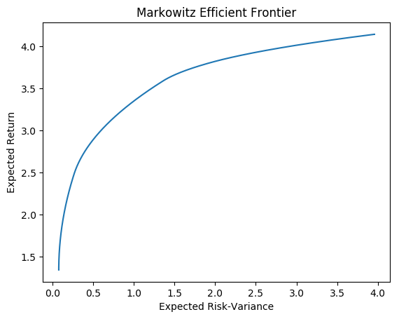

```julia
using PyPlot            #Install PyPlot if you don't have it installed. Pkg.add("PyPlot")
plot(risk,ret)
title("Markowitz Efficient Frontier");
xlabel("Expected Risk-Variance");
ylabel("Expected Return");
```

## Logistic Regression

- I will demonstrate by using the iris data.
- Predict whether the iris species is versicolor using the sepal length and width and petal length and width.

### Convex.jl Code

```julia
using DataFrames, RDatasets, Convex, SCS
iris = dataset("datasets", "iris")
## outcome variable: +1 for versicolor, -1 otherwise
iris[:Y] = [species == "versicolor" ? 1.0 : -1.0 for species in iris[:Species]]
Y = Array(iris[:Y])
## create data matrix with one column for each feature (first column corresponds to offset)
X = [ones(size(iris, 1)) iris[:SepalLength] iris[:SepalWidth] iris[:PetalLength] iris[:PetalWidth]];
```

```julia
# solve the logistic regression problem
n, p = size(X)
beta = Variable(p)
problem = minimize(logisticloss(-Y.*(X*beta)));
solve!(problem, SCSSolver(verbose=false));
problem.optval
beta = beta.value
#using Gadfly
#perm = Base.Sort.sortperm(vec(X*beta.value))
set_default_plot_size(25cm, 12cm)
#plot(layer(x=1:n,y=(Y[perm]+1)/2,Geom.point),layer(x=1:n,y=logistic(X.*beta.value)[perm],Geom.line))
```

[output not shown]

[output cut: 94 more lines]

```
5×1 Array{Float64,2}:
  7.37849
 -0.245357
 -2.79657
  1.31364
 -2.77834
```

## Fidelity in Quantum Information Theory - Introduction

- This example is inspired from a lecture of John Watrous in the [course on Theory of Quantum Information](https://cs.uwaterloo.ca/~watrous/CS766/LectureNotes/08.pdf).
- Fidelity is a measure of the **closeness** of two quantum states.
- The ability to distinguish between the quantum states is equivalent to the ability to distinguish between the classical probability distributions.
- If fidelity between two states is 1, they are the same quantum state.
- **Application**

[figure not shown]

- The Fidelity between two Hermitian semidefinite matrices P and Q is defined as:

$$F(P,Q) = {||{P}^{1/2}{Q}^{1/2} ||}_{tr} = \max\; |trace({P}^{1/2}U{Q}^{1/2})|$$

where the trace norm $||.||_{tr}$ is the sum of the singular values, and the maximization goes over the set of all unitary matrices U.

### Fidelity in Quantum Information Theory - Mathematical Formulation

Fidelity can be expressed as the optimal value of the following complex-valued SDP:

$$ \textbf{maximize} \frac{1}{2} trace(Z+Z^*)$$$$\text{subject to } \left[\begin{array}{cc}P&Z\\{Z}^{*}&Q\end{array}\right] \succeq 0$$$$\text{where } Z \in \mathbf {C}^{n \times n}$$

```julia
n = 20 # Create the data
P = randn(n,n) + im*randn(n,n);
P = P*P';
Q = randn(n,n) + im*randn(n,n);
Q = Q*Q';
```

```julia
Z = ComplexVariable(n,n); # Declare convex variable

objective = 0.5*real(trace(Z+Z'));  # Specify the objective
```

```julia
constraint = [P Z;Z' Q] ⪰ 0;
problem = maximize(objective,constraint);

solve!(problem) # Solve the problem
```

[output not shown]

[output cut: 109 more lines]

[output not shown]

[output not shown]

```julia
# Verify that computer fidelity is equal to actual fidelity
computed_fidelity = evaluate(objective)
P1,P2 = eig(P);
sqP = P2 * diagm([p1^0.5 for p1 in P1]) * P2'
Q1,Q2 = eig(Q)
sqQ = Q2 * diagm([q1^0.5 for q1 in Q1]) * Q2'
actual_fidelity = sum(svd(sqP * sqQ)[2])
diff = computed_fidelity - actual_fidelity
```

```
1.5358510154328542e-5
```